# Compresión de los resultados (B-CNN)

Para comprender mejor lo que ocurre al añadir una rama en una determinada posición a un modelo base como puede ser ResNet-50, se han capturado las activaciones que se presentan en la última capa convolucional del bloque 2 al pasarle una imagen de la especie *Abudefduf abdominalis*, ya que después de este bloque se sitúa una rama para predecir la categoría jerárquica de la especie, en este caso la jerarquía familia.

En primer lugar, importamos las librerías necesarias.

```python
from fastai.vision.all import *
from MapExtrackt import FeatureExtractor
import torch, torchvision, fastai
```

Asignamos las variables de entorno para usar las dos GPUs.

```python
import os; os.environ['CUDA_VISIBLE_DEVICES']='0,1'
```

# ResNet-50 plano

Cargamos el modelo ResNet-50 plano con los pesos de la época 20.

```python
class Resnet50CustomModel(Module):
    def __init__(self, encoder, head):
        self.encoder = encoder
        self.head = head

    def forward(self, x):
        x = self.encoder(x)
        x = self.head(x)
        return x
```

```python
def custom_splitter(model):
    return [params(model.encoder),
            params(model.head)]
```

```python
learn = load_learner('models/species1000-resnet50-nobranch-fepochs1-uepochs20')
```

Creamos el entractor de características de *MapExtrackt*.

```python
fe_flat = FeatureExtractor(learn.model)
```

Seleccionamos las capas que deseamos representar, en este caso solo las convolucionales 2D.

```python
allowed_modules = ['Conv2d']
# allowed_modules = ['Conv2d','BatchNorm2d','ReLU','MaxPool2d']
```

Definimos una función para obtener el nombre de las capas y las listamos, de forma que podamos localizar la capa que se presenta antes de la rama.

```python
def get_name_of_module(module):
    if str(module).find("\n") >= 0:
        name = str(module).split("(")[0] + " (Block)"
    elif str(module).find("\n") < 0:
        name = str(module).split("(")[0]
    return name
```

```python
idx = 0
for module_name, module in learn.model.named_modules():
    name = get_name_of_module(module)
    if name in allowed_modules:
        if isinstance(module, torch.nn.modules.conv.Conv2d):
            size_str = f'=> ({module.in_channels}, {module.out_channels})'
        elif isinstance(module, torch.nn.modules.batchnorm.BatchNorm2d):
            size_str = f'=> ({module.num_features})'
        else:
            size_str = ''

        print(f'[{idx}] {name} ({module_name}) {size_str}')
        idx += 1
```

```
[0] Conv2d (encoder.0) => (3, 64)
[1] Conv2d (encoder.4.0.conv1) => (64, 64)
[2] Conv2d (encoder.4.0.conv2) => (64, 64)
[3] Conv2d (encoder.4.0.conv3) => (64, 256)
[4] Conv2d (encoder.4.0.downsample.0) => (64, 256)
[5] Conv2d (encoder.4.1.conv1) => (256, 64)
[6] Conv2d (encoder.4.1.conv2) => (64, 64)
[7] Conv2d (encoder.4.1.conv3) => (64, 256)
[8] Conv2d (encoder.4.2.conv1) => (256, 64)
[9] Conv2d (encoder.4.2.conv2) => (64, 64)
[10] Conv2d (encoder.4.2.conv3) => (64, 256)
[11] Conv2d (encoder.5.0.conv1) => (256, 128)
[12] Conv2d (encoder.5.0.conv2) => (128, 128)
[13] Conv2d (encoder.5.0.conv3) => (128, 512)
[14] Conv2d (encoder.5.0.downsample.0) => (256, 512)
```

[output cut: 38 more lines]

Vemos que el último Conv2d antes de la rama se encuentra en la posición 23, y presenta unas dimensiones de 128x512.

Mostramos las activaciones de la capa 23, que se encuentra justo antes de la rama de nuestra arquitectura B-CNN.

```python
fe_flat.set_image("images/Abudefduf abdominalis/3047276.jpg", allowed_modules=allowed_modules)
```

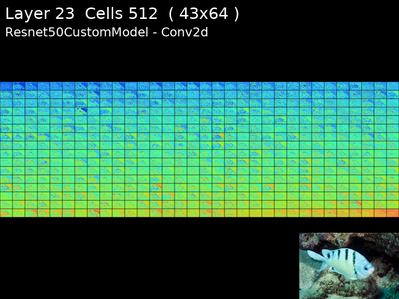

```python
fe_flat[23]
```

Mostramos 20 celdas de esta capa para ver estas en más detalle.

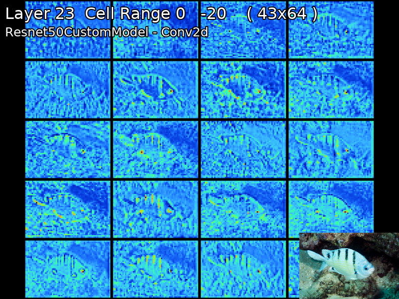

```python
fe_flat[23, 0:20]
```

# ResNet-50 B-CNN

Cargamos el modelo B-CNN con base ResNet-50 y los pesos de la época 20.

```python
def custom_get_y(o):
    fine_label = o['Specie']
    coarse1_label = o['Family']
    return [coarse1_label, fine_label]
```

```python
class Resnet50CustomModel(Module):
    def __init__(self, encoder, head):
        self.encoder = encoder
        self.stem = encoder[0:4]
        self.block1 = body[4]
        self.block2 = body[5]
        self.branch1 = create_head(512*2, len(set(df['Family'])))
        self.block3 = body[6]
        self.block4 = body[7]
        self.head = head

    def forward(self, x):
        x = self.stem(x)
        x = self.block1(x)
        x = self.block2(x)
        coarse1_label = self.branch1(x)
        x = self.block3(x)
        x = self.block4(x)
        fine_label = self.head(x)
        return {
                'fine_label': fine_label,
                'coarse1_label': coarse1_label
               }
```

```python
class CustomCategorize(DisplayedTransform):
    "Reversible transform of category string to `vocab` id"
    loss_func,order=CrossEntropyLossFlat(),1
    def __init__(self, vocab=None, vocab_coarse1=None, vocab_coarse2=None, sort=True, add_na=False, num_y=1):
        store_attr()
        self.vocab = None if vocab is None else CategoryMap(vocab, sort=sort, add_na=add_na)
        self.vocab_coarse1 = None if vocab_coarse1 is None else CategoryMap(vocab_coarse1, sort=sort, add_na=add_na)

    def setups(self, dsets):
        fine_dsets = [d[1] for d in dsets]
        coarse1_dsets = [d[0] for d in dsets]
        if self.vocab is None and dsets is not None: self.vocab = CategoryMap(fine_dsets, sort=self.sort, add_na=self.add_na)
        if self.vocab_coarse1 is None and dsets is not None: self.vocab_coarse1 = CategoryMap(coarse1_dsets, sort=self.sort, add_na=self.add_na)
        self.c = len(self.vocab)

    def encodes(self, o): return {'fine_label': TensorCategory(self.vocab.o2i[o[1]]),
                                  'coarse1_label': TensorCategory(self.vocab_coarse1.o2i[o[0]])
                                 }
    def decodes(self, o): return Category      (self.vocab    [o])
```

```python
def CustomCategoryBlock(vocab=None, sort=True, add_na=False, num_y=1):
    "`TransformBlock` for single-label categorical targets"
    return TransformBlock(type_tfms=CustomCategorize(vocab=vocab, sort=sort, add_na=add_na))
```

```python
def custom_splitter(model):
    return [params(model.stem),
            params(model.block1),
            params(model.block2),
            params(model.block3),
            params(model.block4),
            params(model.head)]
```

```python
def loss_func(out, targ):
    return nn.CrossEntropyLoss(weight=weights)(out['fine_label'], targ['fine_label']) + \
            nn.CrossEntropyLoss(weight=weights_family)(out['coarse1_label'], targ['coarse1_label'])
```

```python
def custom_accuracy(inp, targ, axis=-1):
    pred1,targ1 = flatten_check(inp['fine_label'].argmax(dim=axis), targ['fine_label'])
    acc1 = (pred1 == targ1).float().mean()
    return acc1
```

```python
learn = load_learner('models/species1000-resnet50-branch1-fepochs1-uepochs20')
```

Creamos el entractor de características de *MapExtrackt*.

```python
fe_bcnn = FeatureExtractor(learn.model)
```

Seleccionamos las capas que deseamos representar, en este caso solo las convolucionales 2D.

```python
allowed_modules = ['Conv2d']
```

Definimos una función para obtener el nombre de las capas y las listamos, de forma que podamos localizar la capa que se presenta antes de la rama.

```python
def get_name_of_module(module):
    if str(module).find("\n") >= 0:
        name = str(module).split("(")[0] + " (Block)"
    elif str(module).find("\n") < 0:
        name = str(module).split("(")[0]
    return name
```

```python
idx = 0
for module_name, module in learn.model.named_modules():
    name = get_name_of_module(module)
    if name in allowed_modules:
        if isinstance(module, torch.nn.modules.conv.Conv2d):
            size_str = f'=> ({module.in_channels}, {module.out_channels})'
        elif isinstance(module, torch.nn.modules.batchnorm.BatchNorm2d):
            size_str = f'=> ({module.num_features})'
        else:
            size_str = ''

        print(f'[{idx}] {name} ({module_name}) {size_str}')
        idx += 2
```

```
[0] Conv2d (encoder.0) => (3, 64)
[2] Conv2d (encoder.4.0.conv1) => (64, 64)
[4] Conv2d (encoder.4.0.conv2) => (64, 64)
[6] Conv2d (encoder.4.0.conv3) => (64, 256)
[8] Conv2d (encoder.4.0.downsample.0) => (64, 256)
[10] Conv2d (encoder.4.1.conv1) => (256, 64)
[12] Conv2d (encoder.4.1.conv2) => (64, 64)
[14] Conv2d (encoder.4.1.conv3) => (64, 256)
[16] Conv2d (encoder.4.2.conv1) => (256, 64)
[18] Conv2d (encoder.4.2.conv2) => (64, 64)
[20] Conv2d (encoder.4.2.conv3) => (64, 256)
[22] Conv2d (encoder.5.0.conv1) => (256, 128)
[24] Conv2d (encoder.5.0.conv2) => (128, 128)
[26] Conv2d (encoder.5.0.conv3) => (128, 512)
[28] Conv2d (encoder.5.0.downsample.0) => (256, 512)
```

[output cut: 38 more lines]

Vemos que el último Conv2d antes de la rama se encuentra en la posición 46, y presenta unas dimensiones de 128x512.

Mostramos las activaciones de la capa 46, que se encuentra justo antes de la rama de nuestra arquitectura B-CNN.

```python
fe_bcnn.set_image("images/Abudefduf abdominalis/3047276.jpg", allowed_modules=allowed_modules)
```

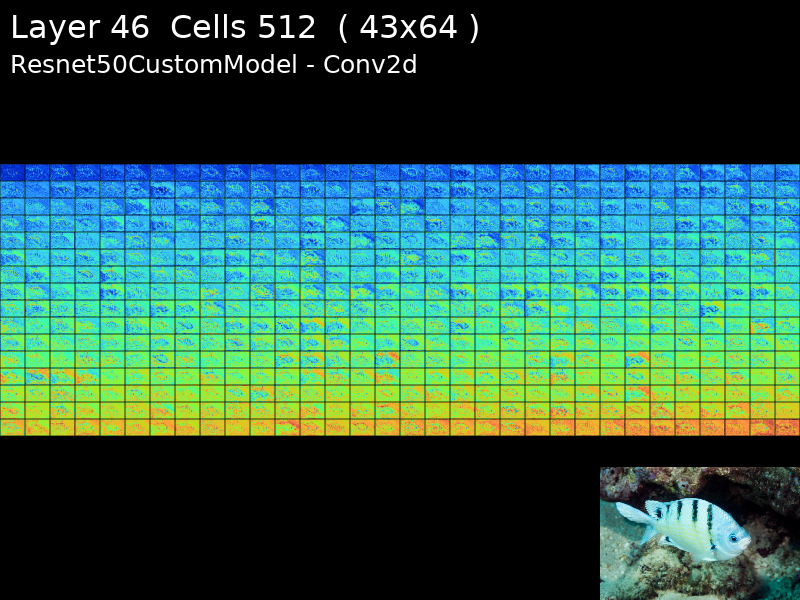

```python
fe_bcnn[46]
```

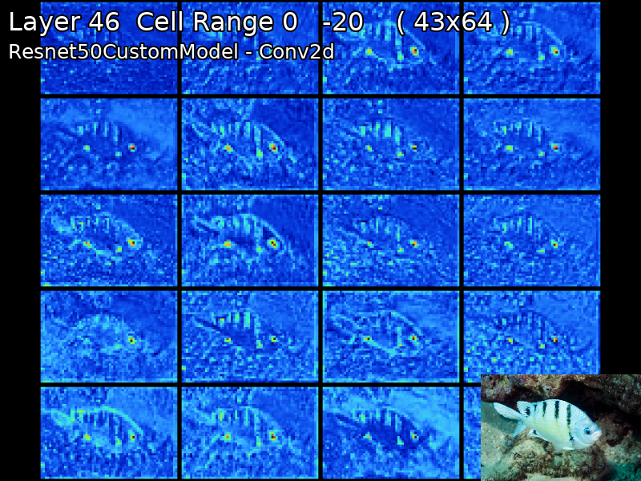

```python
fe_bcnn[46, 0:20]
```

# Comparativa

```python
def display_activations(fe, start, end, layer_no, is_bcnn=False, dst_path=None):
    img_stack = np.array([])
    for i,x in enumerate(range(start, end)):
        img = fe.display_from_map(layer_no=layer_no*2 if is_bcnn else layer_no,
                                  cell_no=x,
                                  outsize=(300,300),
                                  picture_in_picture=False,
                                  write_text="full")
        if i == 0:
            img_stack = img
        else:
            img_stack = np.hstack((img,img_stack))

    img = Image.fromarray(img_stack)
    if dst_path:
        Path(dst_path).parent.mkdir(parents=True, exist_ok=True)
        img.save(dst_path)
    return img
```

```python
start = 57
end = 60
layer_no = 23
```

Mostramos las activaciones del modelo plano basado en ResNet-50.

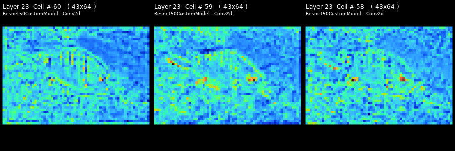

```python
display_activations(fe_flat, start, end, layer_no, is_bcnn=False, dst_path='images/activations/resnet50.jpg')
```

Mostramos las activaciones del modelo B-CNN basado en ResNet-50.

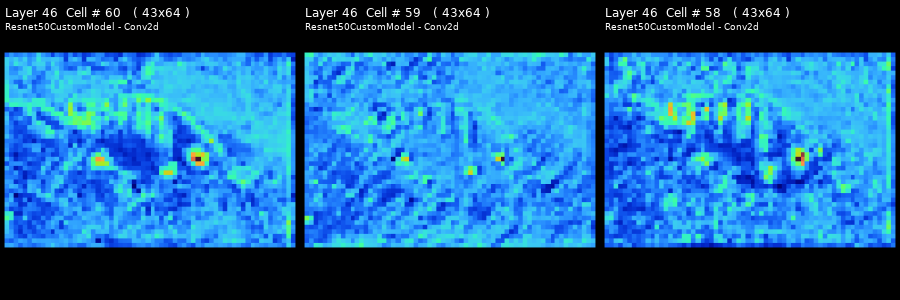

```python
display_activations(fe_bcnn, start, end, layer_no, is_bcnn=True, dst_path='images/activations/resnet50-bcnn.jpg')
```

Como se puede ver en estas figuras, en la parte superior, la cual consta de las activaciones pertenecientes al modelo ResNet-50 sin uso de ramas, se visualizan activaciones más altas en el fondo de la imagen y cualquier parte de la especie, esto puede ser debido a que el modelo busca características muy detalladas que se observan en cualquier parte de la imagen, destacando varias características de la especie, posiblemente dada su complejidad. Sin embargo, en la parte inferior, la cual consta de las activaciones pertenecientes al modelo ResNet-50 con el uso de una rama, se visualizan activaciones altas únicamente en zonas concretas de la especie, como pueden ser en las rayas, aletas u ojos de la especie, dejando el fondo con activaciones muy bajas. Esto puede ser debido a que la clasificación por familia es más sencilla y permite obtenerse con menos características, por lo tanto, al añadir una rama para clasificar esta jerarquía estamos forzando a una parte del modelo a aprender estas características, ayudando así al modelo a identificar características sencillas y concretas que le permitirán posteriormente clasificar la especie con más exactitud.